# chethanassi

Prompt: generate python code to load student dataset and display first few rows

```python
import pandas as pd
```

```python
student_df = pd.read_csv('/content/student-mat.csv', sep=';')
display(student_df.head())
```

|  | school | sex | age | address | famsize | Pstatus | Medu | Fedu | Mjob | Fjob | ... | famrel | freetime | goout | Dalc | Walc | health | absences | G1 | G2 | G3 |
| --- | --- | --- | --- | --- | --- | --- | --- | --- | --- | --- | --- | --- | --- | --- | --- | --- | --- | --- | --- | --- | --- |
| 0 | GP | F | 18 | U | GT3 | A | 4 | 4 | at_home | teacher | ... | 4 | 3 | 4 | 1 | 1 | 3 | 6 | 5 | 6 | 6 |
| 1 | GP | F | 17 | U | GT3 | T | 1 | 1 | at_home | other | ... | 5 | 3 | 3 | 1 | 1 | 3 | 4 | 5 | 5 | 6 |
| 2 | GP | F | 15 | U | LE3 | T | 1 | 1 | at_home | other | ... | 4 | 3 | 2 | 2 | 3 | 3 | 10 | 7 | 8 | 10 |
| 3 | GP | F | 15 | U | GT3 | T | 4 | 2 | health | services | ... | 3 | 2 | 2 | 1 | 1 | 5 | 2 | 15 | 14 | 15 |
| 4 | GP | F | 16 | U | GT3 | T | 3 | 3 | other | other | ... | 4 | 3 | 2 | 1 | 2 | 5 | 4 | 6 | 10 | 10 |

5 rows × 33 columns

Inference: The dataset is successfully loaded. It contains student-related features and their final grade (G3).

Prompt: generate python code to display dataset structure

```python
print(student_df.info())
```

```
<class 'pandas.core.frame.DataFrame'>
RangeIndex: 395 entries, 0 to 394
Data columns (total 33 columns):
 #   Column      Non-Null Count  Dtype
---  ------      --------------  -----
 0   school      395 non-null    object
 1   sex         395 non-null    object
 2   age         395 non-null    int64
 3   address     395 non-null    object
 4   famsize     395 non-null    object
 5   Pstatus     395 non-null    object
 6   Medu        395 non-null    int64
 7   Fedu        395 non-null    int64
 8   Mjob        395 non-null    object
 9   Fjob        395 non-null    object
```

[output cut: 26 more lines]

```python
display(student_df.describe())
```

|  | age | Medu | Fedu | traveltime | studytime | failures | famrel | freetime | goout | Dalc | Walc | health | absences | G1 | G2 | G3 |
| --- | --- | --- | --- | --- | --- | --- | --- | --- | --- | --- | --- | --- | --- | --- | --- | --- |
| count | 395.000000 | 395.000000 | 395.000000 | 395.000000 | 395.000000 | 395.000000 | 395.000000 | 395.000000 | 395.000000 | 395.000000 | 395.000000 | 395.000000 | 395.000000 | 395.000000 | 395.000000 | 395.000000 |
| mean | 16.696203 | 2.749367 | 2.521519 | 1.448101 | 2.035443 | 0.334177 | 3.944304 | 3.235443 | 3.108861 | 1.481013 | 2.291139 | 3.554430 | 5.708861 | 10.908861 | 10.713924 | 10.415190 |
| std | 1.276043 | 1.094735 | 1.088201 | 0.697505 | 0.839240 | 0.743651 | 0.896659 | 0.998862 | 1.113278 | 0.890741 | 1.287897 | 1.390303 | 8.003096 | 3.319195 | 3.761505 | 4.581443 |
| min | 15.000000 | 0.000000 | 0.000000 | 1.000000 | 1.000000 | 0.000000 | 1.000000 | 1.000000 | 1.000000 | 1.000000 | 1.000000 | 1.000000 | 0.000000 | 3.000000 | 0.000000 | 0.000000 |
| 25% | 16.000000 | 2.000000 | 2.000000 | 1.000000 | 1.000000 | 0.000000 | 4.000000 | 3.000000 | 2.000000 | 1.000000 | 1.000000 | 3.000000 | 0.000000 | 8.000000 | 9.000000 | 8.000000 |
| 50% | 17.000000 | 3.000000 | 2.000000 | 1.000000 | 2.000000 | 0.000000 | 4.000000 | 3.000000 | 3.000000 | 1.000000 | 2.000000 | 4.000000 | 4.000000 | 11.000000 | 11.000000 | 11.000000 |
| 75% | 18.000000 | 4.000000 | 3.000000 | 2.000000 | 2.000000 | 0.000000 | 5.000000 | 4.000000 | 4.000000 | 2.000000 | 3.000000 | 5.000000 | 8.000000 | 13.000000 | 13.000000 | 14.000000 |
| max | 22.000000 | 4.000000 | 4.000000 | 4.000000 | 4.000000 | 3.000000 | 5.000000 | 5.000000 | 5.000000 | 5.000000 | 5.000000 | 5.000000 | 75.000000 | 19.000000 | 19.000000 | 20.000000 |

Inference: The dataset contains multiple categorical and numerical features which will be used for prediction.

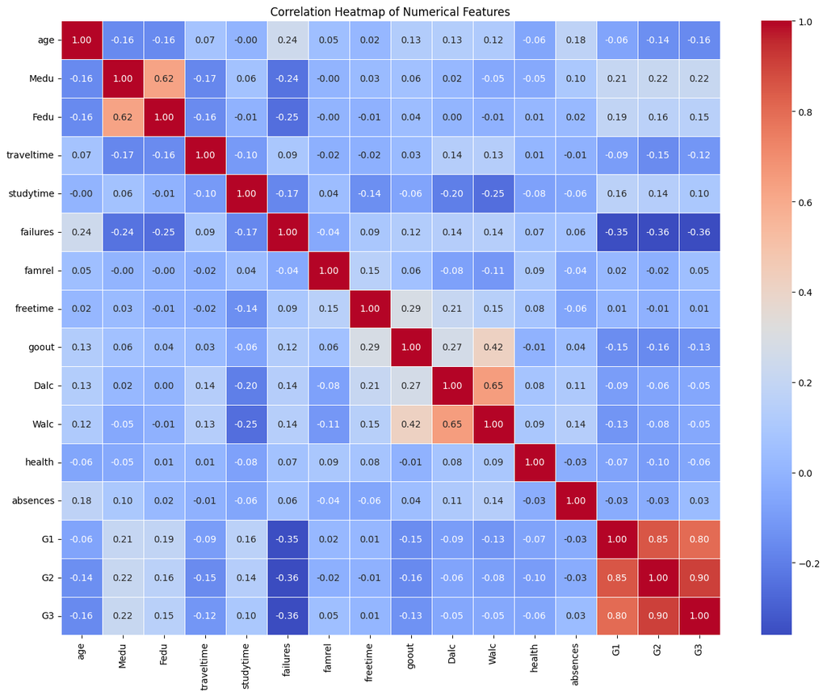

```python
import matplotlib.pyplot as plt
import seaborn as sns

# Select only numerical columns for correlation calculation
numerical_df = student_df.select_dtypes(include=['int64', 'float64'])

# Calculate the correlation matrix
correlation_matrix = numerical_df.corr()

# Plot the heatmap
plt.figure(figsize=(16, 12))
sns.heatmap(correlation_matrix, annot=True, cmap='coolwarm', fmt='.2f', linewidths=.5)
plt.title('Correlation Heatmap of Numerical Features')
plt.show()
```

Prompt: convert categorical features into numerical format

```python
# Select categorical columns
categorical_cols = student_df.select_dtypes(include=['object']).columns

# Apply one-hot encoding
student_df_encoded = pd.get_dummies(student_df, columns=categorical_cols, drop_first=True)

# Display the first few rows of the encoded DataFrame
display(student_df_encoded.head())
```

|  | age | Medu | Fedu | traveltime | studytime | failures | famrel | freetime | goout | Dalc | ... | guardian_mother | guardian_other | schoolsup_yes | famsup_yes | paid_yes | activities_yes | nursery_yes | higher_yes | internet_yes | romantic_yes |
| --- | --- | --- | --- | --- | --- | --- | --- | --- | --- | --- | --- | --- | --- | --- | --- | --- | --- | --- | --- | --- | --- |
| 0 | 18 | 4 | 4 | 2 | 2 | 0 | 4 | 3 | 4 | 1 | ... | True | False | True | False | False | False | True | True | False | False |
| 1 | 17 | 1 | 1 | 1 | 2 | 0 | 5 | 3 | 3 | 1 | ... | False | False | False | True | False | False | False | True | True | False |
| 2 | 15 | 1 | 1 | 1 | 2 | 3 | 4 | 3 | 2 | 2 | ... | True | False | True | False | True | False | True | True | True | False |
| 3 | 15 | 4 | 2 | 1 | 3 | 0 | 3 | 2 | 2 | 1 | ... | True | False | False | True | True | True | True | True | True | True |
| 4 | 16 | 3 | 3 | 1 | 2 | 0 | 4 | 3 | 2 | 1 | ... | False | False | False | True | True | False | True | True | False | False |

5 rows × 42 columns

Inference: Categorical features are converted into numerical values so that machine learning models can process them.

Prompt: select input features and target variable

```python
X = student_df_encoded.drop('G3', axis=1)
y = student_df_encoded['G3']

print(f'Shape of input features (X): {X.shape}')
print(f'Shape of target variable (y): {y.shape}')
```

```
Shape of input features (X): (395, 41)
Shape of target variable (y): (395,)
```

Inference: G3 (final grade) is selected as the target variable for prediction.

```python
from sklearn.model_selection import train_test_split

X_train, X_test, y_train, y_test = train_test_split(X, y, test_size=0.2, random_state=42)
```

Prompt: train Decision Tree model for student performance prediction

```python
from sklearn.tree import DecisionTreeClassifier
from sklearn.metrics import accuracy_score, classification_report

# Initialize the Decision Tree Classifier
dtc_model = DecisionTreeClassifier(random_state=42)

# Train the model
dtc_model.fit(X_train, y_train)

# Make predictions on the test set
y_pred_dtc = dtc_model.predict(X_test)

# Evaluate the model
accuracy_dtc = accuracy_score(y_test, y_pred_dtc)
print(f'Decision Tree Classifier Accuracy: {accuracy_dtc:.2f}')
print('\nClassification Report for Decision Tree Classifier:')
print(classification_report(y_test, y_pred_dtc))
```

```
Decision Tree Classifier Accuracy: 0.30

Classification Report for Decision Tree Classifier:
              precision    recall  f1-score   support

           0       0.29      0.40      0.33         5
           4       0.00      0.00      0.00         0
           5       0.67      0.50      0.57         4
           6       0.33      0.17      0.22         6
           7       0.00      0.00      0.00         1
           8       0.11      0.17      0.13         6
           9       0.12      0.20      0.15         5
          10       0.30      0.27      0.29        11
          11       0.50      0.40      0.44         5
          12       0.00      0.00      0.00         5
          13       0.50      0.20      0.29         5
          14       0.44      0.67      0.53         6
          15       0.56      0.50      0.53        10
          16       0.33      0.25      0.29         4
          17       0.50      0.33      0.40         3
          18       0.00      0.00      0.00         1
          19       0.00      0.00      0.00         2
          20       0.00      0.00      0.00         0

    accuracy                           0.30        79
   macro avg       0.26      0.23      0.23        79
weighted avg       0.34      0.30      0.31        79
```

Inference: Decision Tree model learns patterns from student features and predicts final grades.

Prompt: train Naive Bayes model

```python
from sklearn.naive_bayes import GaussianNB

# Initialize the Gaussian Naive Bayes model
nb_model = GaussianNB()

# Train the model
nb_model.fit(X_train, y_train)

# Make predictions on the test set
y_pred_nb = nb_model.predict(X_test)

# Evaluate the model
accuracy_nb = accuracy_score(y_test, y_pred_nb)
print(f'Naive Bayes Classifier Accuracy: {accuracy_nb:.2f}')
print('\nClassification Report for Naive Bayes Classifier:')
print(classification_report(y_test, y_pred_nb))
```

```
Naive Bayes Classifier Accuracy: 0.22

Classification Report for Naive Bayes Classifier:
              precision    recall  f1-score   support

           0       0.20      0.40      0.27         5
           5       0.00      0.00      0.00         4
           6       0.14      0.17      0.15         6
           7       0.09      1.00      0.17         1
           8       0.27      0.50      0.35         6
           9       0.00      0.00      0.00         5
          10       0.00      0.00      0.00        11
          11       0.00      0.00      0.00         5
          12       0.00      0.00      0.00         5
          13       0.67      0.40      0.50         5
          14       0.50      0.50      0.50         6
          15       0.00      0.00      0.00        10
          16       0.25      0.75      0.38         4
          17       0.14      0.33      0.20         3
          18       0.17      1.00      0.29         1
          19       0.00      0.00      0.00         2

    accuracy                           0.22        79
   macro avg       0.15      0.32      0.18        79
weighted avg       0.15      0.22      0.16        79
```

Inference: Naive Bayes model has been trained and evaluated. Its performance metrics, including accuracy and the classification report, provide insights into its predictive capabilities for student final grades.

Prompt: train Logistic Regression model

```python
from sklearn.linear_model import LogisticRegression
from sklearn.preprocessing import StandardScaler

# Scale the features
scaler = StandardScaler()
X_train_scaled = scaler.fit_transform(X_train)
X_test_scaled = scaler.transform(X_test)

# Initialize the Logistic Regression model with increased max_iter
lr_model = LogisticRegression(random_state=42, max_iter=2000) # Further increased max_iter for convergence

# Train the model
lr_model.fit(X_train_scaled, y_train)

# Make predictions on the test set
y_pred_lr = lr_model.predict(X_test_scaled)

# Evaluate the model
accuracy_lr = accuracy_score(y_test, y_pred_lr)
print(f'Logistic Regression Classifier Accuracy: {accuracy_lr:.2f}')
print('\nClassification Report for Logistic Regression Classifier:')
print(classification_report(y_test, y_pred_lr))
```

```
Logistic Regression Classifier Accuracy: 0.24

Classification Report for Logistic Regression Classifier:
              precision    recall  f1-score   support

           0       0.09      0.20      0.12         5
           5       0.00      0.00      0.00         4
           6       1.00      0.33      0.50         6
           7       0.00      0.00      0.00         1
           8       0.30      0.50      0.38         6
           9       0.00      0.00      0.00         5
          10       0.22      0.18      0.20        11
          11       0.20      0.40      0.27         5
          12       0.00      0.00      0.00         5
          13       0.25      0.20      0.22         5
          14       0.25      0.33      0.29         6
          15       0.44      0.40      0.42        10
          16       0.25      0.25      0.25         4
          17       0.00      0.00      0.00         3
          18       0.20      1.00      0.33         1
          19       0.00      0.00      0.00         2

    accuracy                           0.24        79
   macro avg       0.20      0.24      0.19        79
weighted avg       0.25      0.24      0.23        79
```

Inference: Logistic Regression model has been trained and evaluated. Its performance metrics provide insights into its predictive capabilities for student final grades.

Prompt: train KNN model

```python
from sklearn.neighbors import KNeighborsClassifier
from sklearn.preprocessing import StandardScaler

# Scale the features (if not already scaled in a previous step, though for KNN it's crucial)
# Assuming X_train_scaled and X_test_scaled from Logistic Regression are available and used here.
# If not, this step would be necessary:
# scaler = StandardScaler()
# X_train_scaled = scaler.fit_transform(X_train)
# X_test_scaled = scaler.transform(X_test)

# Initialize the KNN model
knn_model = KNeighborsClassifier(n_neighbors=5) # You can adjust n_neighbors

# Train the model
knn_model.fit(X_train_scaled, y_train)

# Make predictions on the test set
y_pred_knn = knn_model.predict(X_test_scaled)

# Evaluate the model
accuracy_knn = accuracy_score(y_test, y_pred_knn)
print(f'KNN Classifier Accuracy: {accuracy_knn:.2f}')
print('\nClassification Report for KNN Classifier:')
print(classification_report(y_test, y_pred_knn))
```

```
KNN Classifier Accuracy: 0.10

Classification Report for KNN Classifier:
              precision    recall  f1-score   support

           0       0.10      0.20      0.13         5
           5       0.00      0.00      0.00         4
           6       0.67      0.33      0.44         6
           7       0.00      0.00      0.00         1
           8       0.00      0.00      0.00         6
           9       0.00      0.00      0.00         5
          10       0.17      0.36      0.24        11
          11       0.00      0.00      0.00         5
          12       0.00      0.00      0.00         5
          13       0.20      0.20      0.20         5
          14       0.00      0.00      0.00         6
          15       0.00      0.00      0.00        10
          16       0.00      0.00      0.00         4
          17       0.00      0.00      0.00         3
          18       0.00      0.00      0.00         1
          19       0.00      0.00      0.00         2

    accuracy                           0.10        79
   macro avg       0.07      0.07      0.06        79
weighted avg       0.09      0.10      0.09        79
```

Inference: K-Nearest Neighbors (KNN) model has been trained and evaluated. Its performance metrics provide insights into its predictive capabilities for student final grades.

Prompt: train ANN model

```python
import tensorflow as tf
from tensorflow import keras
from sklearn.metrics import classification_report, accuracy_score

# Ensure target variable is integer type for sparse_categorical_crossentropy
y_train_int = y_train.astype(int)
y_test_int = y_test.astype(int)

# Define the ANN model
model = keras.Sequential([
    keras.layers.Dense(128, activation='relu', input_shape=(X_train_scaled.shape[1],)),
    keras.layers.Dropout(0.2),
    keras.layers.Dense(64, activation='relu'),
    keras.layers.Dropout(0.2),
    keras.layers.Dense(y_train_int.max() + 1, activation='softmax') # Output layer for 0-20 grades
])

# Compile the model
model.compile(optimizer='adam',
              loss='sparse_categorical_crossentropy',
              metrics=['accuracy'])

# Train the model
history = model.fit(X_train_scaled, y_train_int, epochs=50, batch_size=32, validation_split=0.1, verbose=0)

# Evaluate the model
loss, accuracy_ann = model.evaluate(X_test_scaled, y_test_int, verbose=0)
print(f'ANN Classifier Accuracy: {accuracy_ann:.2f}')

# Make predictions
y_pred_proba_ann = model.predict(X_test_scaled, verbose=0)
y_pred_ann = tf.argmax(y_pred_proba_ann, axis=1)

print('\nClassification Report for ANN Classifier:')
print(classification_report(y_test_int, y_pred_ann, zero_division=0))
```

```
ANN Classifier Accuracy: 0.18

Classification Report for ANN Classifier:
              precision    recall  f1-score   support

           0       0.17      0.40      0.24         5
           5       0.00      0.00      0.00         4
           6       1.00      0.33      0.50         6
           7       0.00      0.00      0.00         1
           8       0.20      0.17      0.18         6
           9       1.00      0.20      0.33         5
          10       0.40      0.18      0.25        11
          11       0.00      0.00      0.00         5
          12       0.10      0.20      0.13         5
          13       0.14      0.20      0.17         5
          14       0.00      0.00      0.00         6
          15       0.38      0.30      0.33        10
          16       0.00      0.00      0.00         4
          17       0.00      0.00      0.00         3
          18       0.17      1.00      0.29         1
          19       0.00      0.00      0.00         2

    accuracy                           0.18        79
   macro avg       0.22      0.19      0.15        79
weighted avg       0.29      0.18      0.19        79
```

Prompt: compare all models

```
--- Model Comparison ---
```

|  | Model | Accuracy |
| --- | --- | --- |
| 0 | Decision Tree | 0.303797 |
| 2 | Logistic Regression | 0.240506 |
| 1 | Naive Bayes | 0.215190 |
| 4 | ANN | 0.177215 |
| 3 | KNN | 0.101266 |

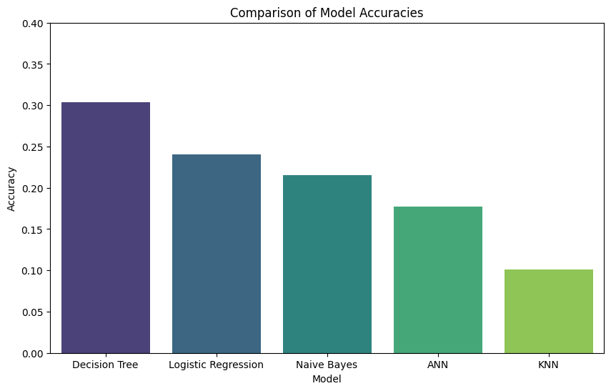

```python
import pandas as pd
import matplotlib.pyplot as plt
import seaborn as sns

# Create a dictionary to store model accuracies
model_accuracies = {
    'Decision Tree': accuracy_dtc,
    'Naive Bayes': accuracy_nb,
    'Logistic Regression': accuracy_lr,
    'KNN': accuracy_knn,
    'ANN': accuracy_ann
}

# Convert to a pandas DataFrame for better visualization
accuracy_df = pd.DataFrame(list(model_accuracies.items()), columns=['Model', 'Accuracy'])
accuracy_df = accuracy_df.sort_values(by='Accuracy', ascending=False)

print('\n--- Model Comparison ---\n')
display(accuracy_df)

# Plot the accuracies
plt.figure(figsize=(10, 6))
sns.barplot(x='Model', y='Accuracy', data=accuracy_df, hue='Model', palette='viridis', legend=False)
plt.title('Comparison of Model Accuracies')
plt.xlabel('Model')
plt.ylabel('Accuracy')
plt.ylim(0, 0.4) # Adjust y-axis limit based on observed accuracies
plt.show()
```

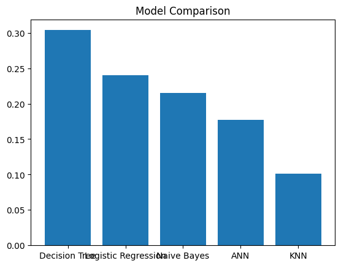

```python
import matplotlib.pyplot as plt

plt.bar(accuracy_df["Model"], accuracy_df["Accuracy"])
plt.title("Model Comparison")
plt.show()
```